# Multilevel Model With Experimental Data

Paul Bloom

7/12/2021

# An experimental dataset

Here, we’ll look at some pilot data from an experiment! In this experiment, the researchers manipulated the type of music that participants were exposed to – either a *familiar* condition where songs were by artists that participants had previously indicated they knew well, an *unfamiliar* condition where songs were by artists that participants had reported not knowing, and a *control* condition where the clips were not songs at all but instead weather and traffic clips. For today’s purposes, we’ll just focus on the *familiar* and *unfamiliar* conditions.

In particular, we’ll use multilevel models here because the data are *nested*! This is a *within-participants* study where each participant completed multiple listening trials in each condition. Because of this, a multilevel model will help us take into account that each person might respond differently to the manipulation (while still estimating the group-wide response)!

# Our question

Here we’ll ask the question: *did participants actually rate the clips in the ‘familiar’ condition as more familiar?*

Participants rated their familiarity with each audio clip on a likert-type scale from 1-5

```r
library(tidyverse)
library(rstanarm)
library(tidybayes)
```

```r
df = read_csv('https://raw.githubusercontent.com/pab2163/amfm_public/master/pilot_data/pilot_responses.csv') %>%
  dplyr::filter(condition != 'C', is.na(Skipped)) %>%
  dplyr::select(Year, Title, Artist, Genre, condition, musicValence, familiarityRating, participantID) %>%
  dplyr::mutate(condition = dplyr::recode(condition, 'F' = 'Familiar', 'U' = 'Unfamiliar'))
head(df, 3)
```

```
## # A tibble: 3 x 8
##    Year Title Artist Genre condition musicValence familiarityRati… participantID
##   <dbl> <chr> <chr>  <chr> <chr>            <dbl>            <dbl> <chr>
## 1  1965 The … The A… R&B/… Unfamili…            5                1 pilot007
## 2  1964 Haun… Jumpi… Rock  Unfamili…            5                1 pilot007
## 3  1964 Hi-H… Tommy… Pop   Unfamili…            6                1 pilot007
```

There were only 6 participants here – not a big group. However, each participant listened to 15 clips in each condition, so there is a larger amount of *nested* data. Let’s take a look:

```r
df %>%
  dplyr::group_by(condition, participantID) %>%
  count()
```

```
## # A tibble: 12 x 3
## # Groups:   condition, participantID [12]
##    condition  participantID     n
##    <chr>      <chr>         <int>
##  1 Familiar   pilot007         15
##  2 Familiar   pilot008         15
##  3 Familiar   pilot010         15
##  4 Familiar   pilot011         15
##  5 Familiar   pilot012         13
##  6 Familiar   pilot013         15
##  7 Unfamiliar pilot007         15
##  8 Unfamiliar pilot008         15
##  9 Unfamiliar pilot010         13
## 10 Unfamiliar pilot011         13
## 11 Unfamiliar pilot012         15
## 12 Unfamiliar pilot013         15
```

Some participants have fewer than 15 trials because they skipped trials, but we can see the nesting structure here.

# Now, let’s make a model of participants’ self-reported familiarity as a function of condition

Since we *manipulated* condition here, we can actually determine the **causal effect** of our condition manipulation, unlike some of the other analyses we’ve done before with non-experimental data.

Here, we’ll give random “slopes” for condition for each participant

```r
fm = rstanarm::stan_glmer(data = df, familiarityRating ~ condition + (condition | participantID))
```

```r
m_summary = summary(fm, probs = c(.025, .975))
m_summary[1:5,]
```

```
##                                                      mean        mcse        sd
## (Intercept)                                    4.35713296 0.005815964 0.2733187
## conditionUnfamiliar                           -2.09425571 0.005340004 0.2578036
## b[(Intercept) participantID:pilot007]         -0.39680427 0.006391725 0.3255558
## b[conditionUnfamiliar participantID:pilot007] -0.09482656 0.005402508 0.2819336
## b[(Intercept) participantID:pilot008]          0.39609775 0.007027979 0.3283305
##                                                     2.5%      97.5% n_eff
## (Intercept)                                    3.8006187  4.8958454  2208
## conditionUnfamiliar                           -2.6117459 -1.5908164  2331
## b[(Intercept) participantID:pilot007]         -1.0893026  0.2171927  2594
## b[conditionUnfamiliar participantID:pilot007] -0.7062757  0.4569368  2723
## b[(Intercept) participantID:pilot008]         -0.1982755  1.1047370  2183
##                                                    Rhat
## (Intercept)                                   0.9995695
## conditionUnfamiliar                           1.0019855
## b[(Intercept) participantID:pilot007]         0.9995981
## b[conditionUnfamiliar participantID:pilot007] 1.0007670
## b[(Intercept) participantID:pilot008]         0.9996300
```

# Use `spread_draws()` to get the full posterior distribution for the effect of unfamiliar > familiar condition on self-reported music familiarity

We can actually say the word `effect` here because we manipulated music!

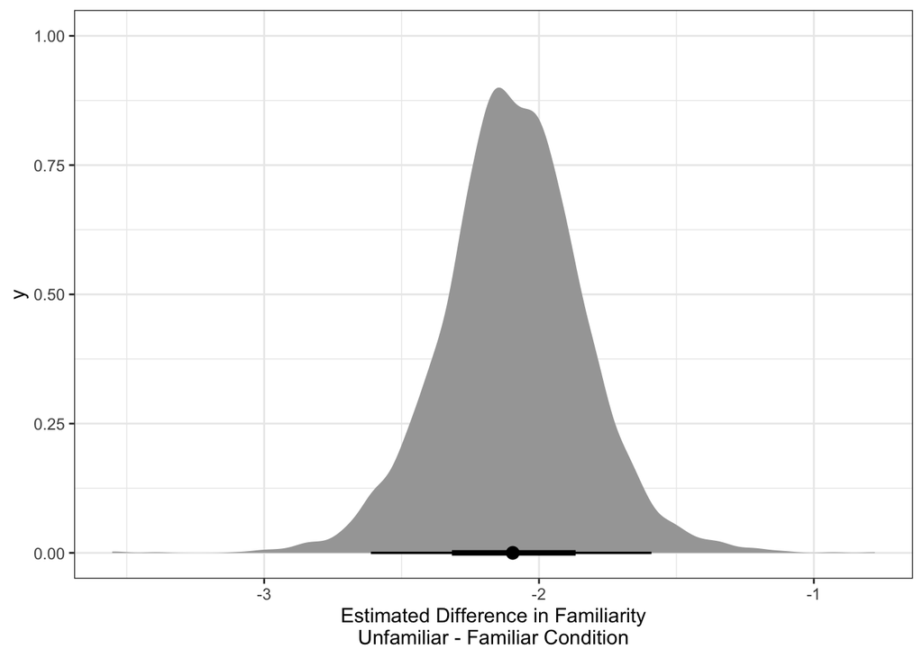

```r
condition_posterior = fm %>% spread_draws(conditionUnfamiliar)


ggplot(condition_posterior, aes(x = conditionUnfamiliar)) +
  stat_halfeye() +
  labs(x = 'Estimated Difference in Familiarity\nUnfamiliar - Familiar Condition') +
  theme_bw()
```

# Plot the predictions

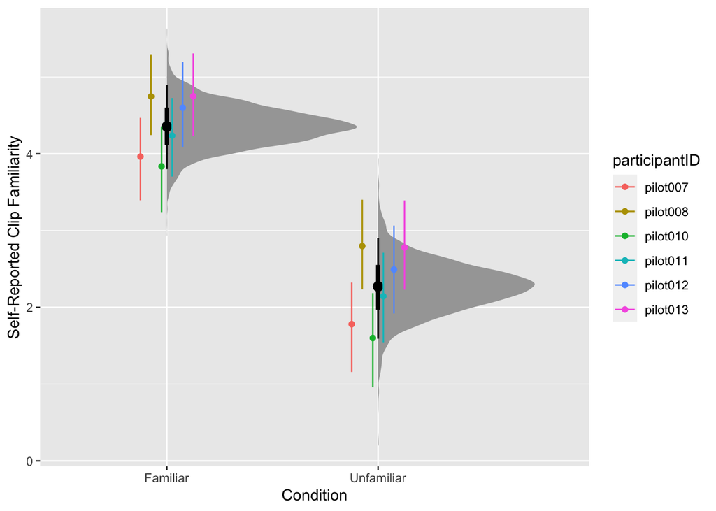

```r
pred_frame = data.frame(condition = c('Unfamiliar', 'Familiar'))
pred_frame_participants = expand.grid(condition = c('Unfamiliar', 'Familiar'), participantID = unique(df$participantID), stringsAsFactors = FALSE)

fm_predictions = tidybayes::add_fitted_draws(newdata = pred_frame, model = fm, re_formula = NA)
fm_predictions_participant = tidybayes::add_fitted_draws(model = fm, newdata = pred_frame_participants) %>%
  median_qi()
ggplot(fm_predictions, aes(x = condition, y = .value)) +
  stat_halfeye() +
  geom_point(data = fm_predictions_participant,
                     aes(x = condition, y = .value, color = participantID),
                     position = position_dodge(.3)) +
   geom_errorbar(data = fm_predictions_participant,
                     aes(x = condition, y = .value, ymin = .lower, ymax = .upper, color = participantID),
                     position = position_dodge(.3),
                     width = 0) +
  labs(y = 'Self-Reported Clip Familiarity', x = 'Condition')
```

# What about the random ‘slopes’

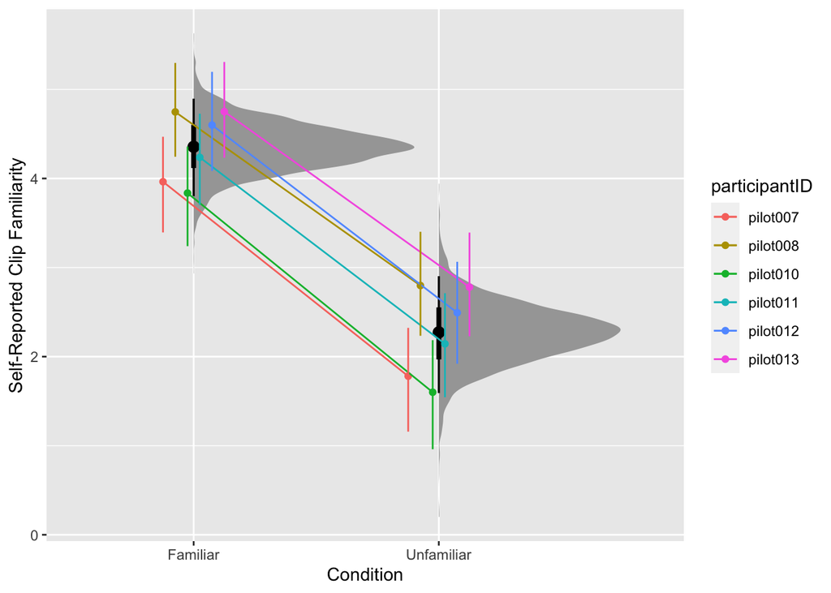

```r
ggplot(fm_predictions, aes(x = condition, y = .value)) +
  stat_halfeye() +
  geom_point(data = fm_predictions_participant,
                     aes(x = condition, y = .value, color = participantID),
                     position = position_dodge(.3)) +
   geom_line(data = fm_predictions_participant,
                     aes(x = condition, y = .value, color = participantID, group = participantID),
                     position = position_dodge(.3)) +
   geom_errorbar(data = fm_predictions_participant,
                     aes(x = condition, y = .value, ymin = .lower, ymax = .upper, color = participantID),
                     position = position_dodge(.3),
                     width = 0) +
  labs(y = 'Self-Reported Clip Familiarity', x = 'Condition')
```

# Comparing the model predictions to the raw data

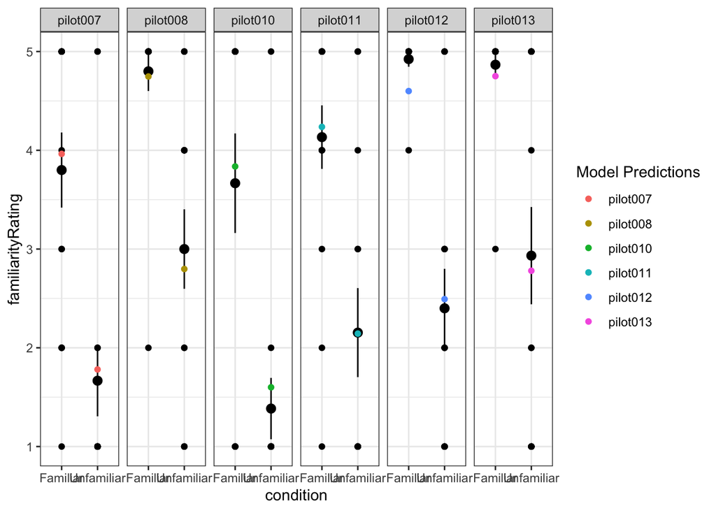

```r
ggplot(data = df, aes(x = condition, y = familiarityRating)) +
  geom_point() +
  stat_summary(fun.data = mean_se) +
  geom_point(data = fm_predictions_participant,
                     aes(x = condition, y = .value, color = participantID),
                     position = position_dodge(.3)) +
  facet_grid(~participantID) +
  labs(color = 'Model Predictions') +
  theme_bw()
```

# Posterior predictive check

One thing that is usually a good idea is to run the `pp_check()` function (I know…) to do a graphical *posterior predictive check*. What is this for?

Basicallly, this means we are checking whether the distribution of the model’s predictions for the outcome variable (familiarity ratings here) matches the actual distribution of the outcome variable

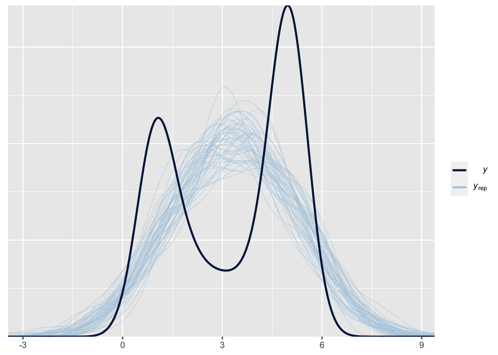

```r
pp_check(fm)
```

Hmm, unfortunately this model doesn’t seem to me making some great assumptions! Just something to think about … do we care that our model is making impossible predictions with our dataset?

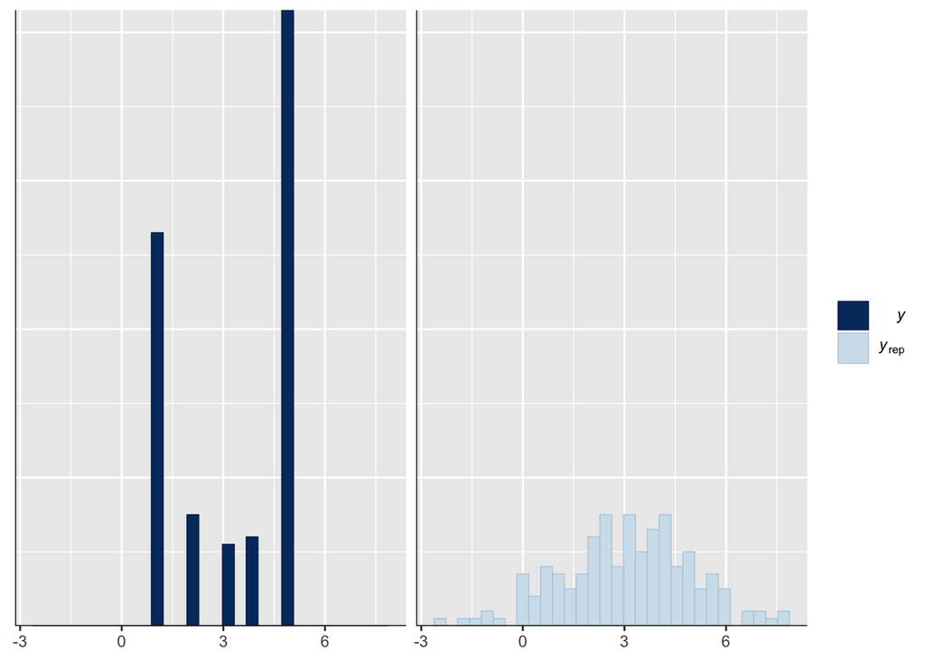

```r
pp_check(fm, plotfun = 'ppc_hist', nreps = 1)
```